# PCA y SMCCA-GS aplicado sobre una cohorte ómica de pacientes del proyecto ROSMAP

JLA

2024-06-05

# 1 Introducción

En este fichero vamos a aplicar dos técnicas de reducción de la dimensionalidad a tres conjuntos de datos sobre las muestras cerebrales de personas fallecidas. Estos conjuntos de datos son: `ROSMAP_RINPMIAGESEX_resids`, nos da como predictores información sobre la genética de los pacientes; `ROSMAP_Metabolon_HD4_Brain514_assay_data`, proporciona datos de metabolómica (información sobre los metabolitos); y `3.cleanDat`, proporciona información de proteómica.

Las dos técnicas que vamos a utilizar son la técnica clásica PCA y SMCCA-GS, una variante de CCA (canonical correlation analysis) denominada “Sparse Multiple Canonical Correlation Analysis”, que permite aplicar CCA a varios conjuntos de datos y que, además, incluye la aplicación de la técnica de ortogonalización de Gramm-Schmidt para mejorar la ortogonalidad entre las variables canónicas.

El objetivo que perseguimos es comprobar si SMCCA-GS devuelve mejores resultados que PCA. Para ello, vamos a aplicar ambas técnicas a todos los conjuntos de datos y compararemos los resultados obtenidos. Tendremos además en cuenta como variable de clase al predictor `cogdx` del conjunto de datos `ROSMAP_clinical`, el cual nos indica el diagnóstico clínico final del paciente.

# 2 Preparación de los datos

Antes de poder aplicar cualquiera de los dos métodos hemos de realizar un preprocesado de los datos, en el que incluiremos, entre otros puntos, la eliminación de las columnas que solamente contengan ceros y de aquellos pacientes para los cuales falten datos necesarios:

Empezamos cargando las librerías que vamos a utilizar y dos funciones, una de ellas desarrollada por nosotros y otra necesaria para la aplicación de SMCCA-GS:

```r
# Cargamos las librerías que vamos a utilizar
library(lattice)
library(ggplot2)
library(reshape2)
library(caret)
library(gridExtra)
library(fpc)
library(plyr)
library(Rmisc)
library(tidyverse)
library(VIM)
# Función para aplicar SMCCA-GS
source("function_SMCCA-GS_SSMCCA.R")
# Función desarrollada por nosotros
source("function_calcular_distancias.R")
```

A continuación, cargamos los conjuntos de datos con los que vamos a trabajar:

```r
# Cargamos los conjuntos de datos
rinpmiagesex = readRDS("ROSMAP_RINPMIAGESEX_resids.rds")
metabolon <- read.table("ROSMAP_Metabolon_HD4_Brain514_assay_data.csv", sep=",", header=T, na.strings = "")
cleandat <- read.table("3.cleanDat.csv", sep=",", header=T, na.strings = "")

# Indicamos que `rinpmiagesex` se guarde como un "data.frame"
rinpmiagesex <- as.data.frame(rinpmiagesex)
```

Indicamos que las cadenas sin valor se guarden como “NA”:

```r
# Nos aseguramos de que todas las cadenas sin valor se guarden como "NA"
rinpmiagesex[rinpmiagesex == "NA"] <- NA
metabolon[metabolon == "NA"] <- NA
cleandat[cleandat == "NA"] <- NA
```

Los conjuntos de datos `metabolon` y `rinpmiagesex` tienen a un paciente asignado por fila, mientras que `cleandat` tiene a los pacientes como columnas. Por tanto, vamos a voltear `cleandat` para que sus filas sean pacientes.

```r
X <- cleandat$X
cleandat$X <- NULL
cleandat <- as.data.frame(t(cleandat))
names(cleandat) <- X
```

Obtenemos los pacientes comunes a los tres conjuntos de datos:

```r
# La identificación de los pacientes en "metabolon" se halla en la columna "individualID"
# La identificación de los pacientes en "cleanDat" se obtiene a través de la columna "projID" de "0.Traits-AGE_CENSORED"
# La identificación de los pacientes en "rinpmiagesex" se obtiene a través de la columna "projID" de "ROSMAP_RINPMIAGESEX_covs"

# Cargamos el conjunto de datos "0.Traits-AGE_CENSORED"
RMP_proteomics_0_Traits <- read.table("0.Traits-AGE_CENSORED.csv", sep=",", header=T, na.strings = "")

# Tomamos los pacientes de "RMP_proteomics_0_Traits" que se hallan en "cleandat"
length(intersect(RMP_proteomics_0_Traits$SampleID, row.names(cleandat)))
```

```
## [1] 323
```

```r
aux_AA <- intersect(RMP_proteomics_0_Traits$SampleID, row.names(cleandat))
RMP_proteomics_0_Traits <- RMP_proteomics_0_Traits[RMP_proteomics_0_Traits$SampleID %in% aux_AA, ]
length(rownames(RMP_proteomics_0_Traits))
```

```
## [1] 323
```

```r
# Tomamos los pacientes de "ROSMAP_RINPMIAGESEX_covs" que se hallan en "rinpmiagesex"
RMP_covs <- readRDS("ROSMAP_RINPMIAGESEX_covs.rds")
aux_BB <- intersect(RMP_covs$mrna_id, row.names(rinpmiagesex))
RMP_covs <- RMP_covs[RMP_covs$mrna_id %in% aux_BB, ]
length(intersect(RMP_covs$mrna_id, row.names(rinpmiagesex)))
```

```
## [1] 342
```

```r
# Tomamos los pacientes de "ROSMAP_clinical" que se hallan en "metabolon"
clinical <- read.table("ROSMAP_clinical.csv", sep=",", header=T, na.strings = "")
aux_CC <- intersect(clinical$individualID, metabolon$individualID)
clinical <- clinical[clinical$individualID %in% aux_CC, ]
length(rownames(clinical))
```

```
## [1] 514
```

```r
# Tomamos los pacientes comunes entre "cleanDat", "metabolon" y "rinpmiagesex"
interseccion_projid <- intersect(intersect(RMP_proteomics_0_Traits$projid, clinical$projid), RMP_covs$projid)
length(interseccion_projid)
```

```
## [1] 69
```

Elegimos de cada conjunto de datos (`metabolon`, `cleandat` y `rinpmiagesex`), los pacientes comunes:

```r
# Actualizamos primero los conjuntos de datos que hemos utilizado como puente
RMP_proteomics_0_Traits <- RMP_proteomics_0_Traits[RMP_proteomics_0_Traits$projid %in% interseccion_projid, ]
RMP_covs <- RMP_covs[RMP_covs$projid %in% interseccion_projid, ]
clinical <- clinical[clinical$projid %in% interseccion_projid, ]

# Actualizamos los conjuntos de datos `metabolon`, `cleandat` y `rinpmiagesex`
cleandat <- cleandat[rownames(cleandat) %in% intersect(rownames(cleandat), RMP_proteomics_0_Traits$SampleID), ]
rinpmiagesex <- rinpmiagesex[rownames(rinpmiagesex) %in% intersect(rownames(rinpmiagesex), RMP_covs$mrna_id), ]
metabolon <- metabolon[metabolon$individualID %in% intersect(metabolon$individualID, clinical$individualID), ]

# Eliminamos un valor con "outliers"
cleandat <- cleandat[-c(61),]
rinpmiagesex <- rinpmiagesex[-c(61),]
metabolon <- metabolon[-c(61),]
clinical <- clinical[-c(61),]
```

Veamos cuáles son las nuevas dimensiones de los conjuntos de datos:

```r
dim(cleandat)
```

```
## [1]   68 8812
```

```r
dim(rinpmiagesex)
```

```
## [1]    68 12556
```

```r
dim(metabolon)
```

```
## [1]   68 1063
```

Comprobamos si hay “NAs”:

```r
# Comprobamos si hay NAs
sum(is.na(cleandat))
```

```
## [1] 43205
```

```r
sum(is.na(rinpmiagesex))
```

```
## [1] 0
```

```r
sum(is.na(metabolon))
```

```
## [1] 22883
```

```r
sum(is.na(clinical$cogdx))
```

```
## [1] 0
```

Mostramos en dos histogramas el número de predictores según la cantidad relativa de valores nulos:

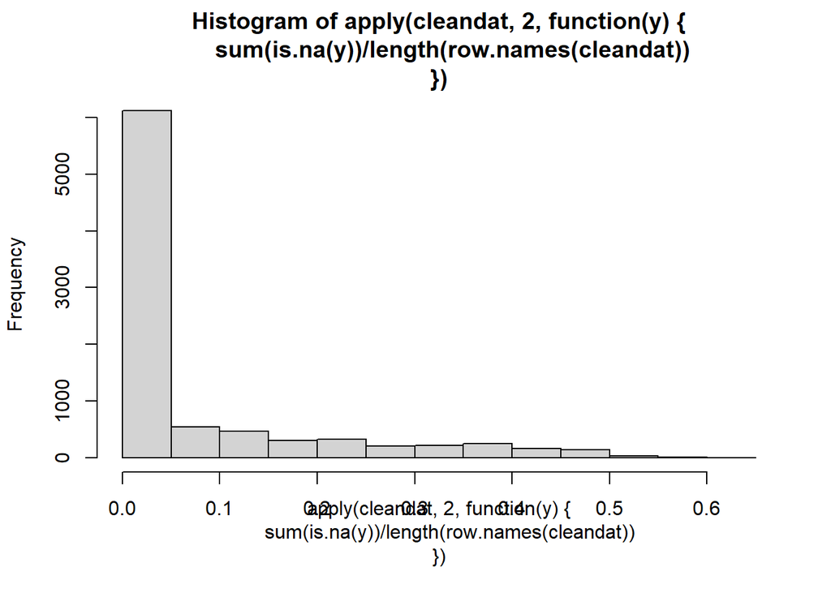

```r
# Calculamos el número de NA's por predictor
hist(apply(cleandat, 2, function(y){sum(is.na(y)) / length(row.names(cleandat))}))
```

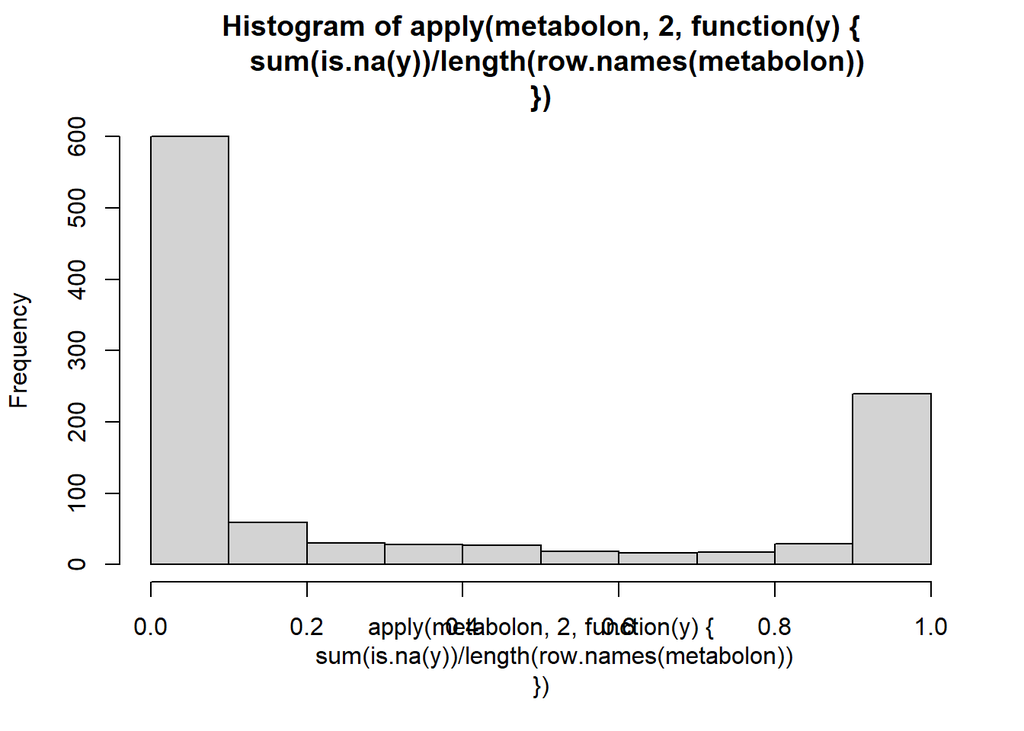

```r
hist(apply(metabolon, 2, function(y){sum(is.na(y)) / length(row.names(metabolon))}))
```

Eliminamos todos los predictores de `cleandat` y de `metabolon` con más de un 10% de valores nulos:

```r
# Calculamos el número de predictores de `cleandat` con más de un 10% de valores nulos
aux5 <- apply(cleandat, 2, function(y){sum(is.na(y)) / length(row.names(cleandat)) >= 0.1})
length(aux5[aux5==TRUE])
```

```
## [1] 2148
```

```r
# Calculamos el número de predictores de `metabolon` con más de un 10% de valores nulos
aux6 <- apply(metabolon, 2, function(y){sum(is.na(y)) / length(row.names(metabolon)) >= 0.1})
length(aux6[aux6==TRUE])
```

```
## [1] 463
```

```r
# Eliminamos los predictores con valores nulos
cleandat <- cleandat[, names(cleandat) %in% names(aux5[aux5==FALSE])]
metabolon <- metabolon[, (names(metabolon) %in% names(aux6[aux6==FALSE]))]

# Mostramos las nuevas dimensiones de `cleandat` y de `metabolon`
dim(cleandat)
```

```
## [1]   68 6664
```

```r
dim(metabolon)
```

```
## [1]  68 600
```

Indicamos que las columnas de `cleandat` son numéricas:

```r
cleandat.prep <- as.data.frame(sapply(cleandat, as.numeric))
```

En `metabolon` nos quedamos solamente con las variables numéricas:

```r
metabolon.prep <- as.data.frame(sapply(metabolon[, 8:479], as.numeric))
```

En `rinpmiagesex` no hace falta modificar ningún dato:

```r
rinpmiagesex.prep <- rinpmiagesex
```

Reemplazamos los valores nulos de `cleandat` y `metabolon` por la mediana del predictor al que pertenezcan:

```r
cleandat.prep <- cleandat.prep %>% mutate(across(where(is.numeric), ~replace_na(., median(., na.rm=TRUE))))
metabolon.prep <- metabolon.prep %>% mutate(across(where(is.numeric), ~replace_na(., median(., na.rm=TRUE))))
```

Comprobamos que ya no queden valores nulos:

```r
# Calculamos el número de predictores de `cleandat_prueba` con algún valor nulo
aux9 <- apply(cleandat.prep, 2, function(y){sum(is.na(y)) > 0})
length(aux9[aux9==TRUE])
```

```
## [1] 0
```

```r
# Calculamos el número de predictores de `metabolon_prueba` con algún valor nulo
aux10 <- apply(metabolon.prep, 2, function(y){sum(is.na(y)) > 0})
length(aux10[aux10==TRUE])
```

```
## [1] 0
```

# 3 PCA

En esta sección, vamos a aplicar la técnica PCA a los conjuntos de datos `cleandat`, `rinpmiagesex` y `metabolon`.

## 3.1 PCA sobre `cleandat`

Comprobamos si tenemos algún predictor categórico:

```r
which(sapply(colnames(cleandat.prep), function(x) class(cleandat.prep[[x]]) != "numeric") == TRUE)
```

```
## named integer(0)
```

Dado que no hay ninguno, aplicamos PCA:

```r
pca_result_cleandat <- prcomp(cleandat.prep, scale = TRUE, rank=6)
```

Podemos ver la desviación estándar de cada componente principal.

```r
pca_result_cleandat$sdev
```

```
##  [1] 2.605153e+01 2.065276e+01 1.877357e+01 1.817537e+01 1.592903e+01
##  [6] 1.481914e+01 1.378276e+01 1.351713e+01 1.261494e+01 1.254369e+01
## [11] 1.199097e+01 1.185072e+01 1.163298e+01 1.100544e+01 1.084211e+01
## [16] 1.047960e+01 1.029251e+01 1.025697e+01 9.957405e+00 9.806314e+00
## [21] 9.702004e+00 9.482301e+00 9.305208e+00 9.169571e+00 8.906064e+00
## [26] 8.792683e+00 8.701514e+00 8.646249e+00 8.540121e+00 8.441178e+00
## [31] 8.201843e+00 8.117826e+00 8.047324e+00 8.018764e+00 7.836523e+00
## [36] 7.715355e+00 7.713180e+00 7.536043e+00 7.498023e+00 7.355866e+00
## [41] 7.254082e+00 7.184136e+00 7.121182e+00 7.022656e+00 7.010368e+00
## [46] 6.941580e+00 6.869680e+00 6.837437e+00 6.758622e+00 6.708141e+00
## [51] 6.604361e+00 6.561991e+00 6.494057e+00 6.489246e+00 6.426082e+00
## [56] 6.292864e+00 6.178394e+00 6.117777e+00 6.086982e+00 6.035400e+00
## [61] 5.970533e+00 5.931682e+00 5.910157e+00 5.805968e+00 5.736795e+00
## [66] 5.721279e+00 5.563256e+00 2.255705e-14
```

La varianza explicada por cada componente principal se obtiene mediante la cuadratura de estos valores:

```r
(VE_cleandat <- pca_result_cleandat$sdev^2)
```

```
##  [1] 6.786823e+02 4.265364e+02 3.524470e+02 3.303440e+02 2.537339e+02
##  [6] 2.196069e+02 1.899645e+02 1.827128e+02 1.591368e+02 1.573442e+02
## [11] 1.437832e+02 1.404396e+02 1.353262e+02 1.211198e+02 1.175513e+02
## [16] 1.098220e+02 1.059358e+02 1.052053e+02 9.914992e+01 9.616379e+01
## [21] 9.412889e+01 8.991403e+01 8.658689e+01 8.408103e+01 7.931797e+01
## [26] 7.731127e+01 7.571635e+01 7.475762e+01 7.293366e+01 7.125349e+01
## [31] 6.727023e+01 6.589910e+01 6.475943e+01 6.430057e+01 6.141110e+01
## [36] 5.952670e+01 5.949314e+01 5.679194e+01 5.622034e+01 5.410876e+01
## [41] 5.262171e+01 5.161182e+01 5.071123e+01 4.931769e+01 4.914526e+01
## [46] 4.818553e+01 4.719250e+01 4.675055e+01 4.567897e+01 4.499916e+01
## [51] 4.361759e+01 4.305973e+01 4.217278e+01 4.211031e+01 4.129452e+01
## [56] 3.960013e+01 3.817256e+01 3.742719e+01 3.705135e+01 3.642605e+01
## [61] 3.564727e+01 3.518486e+01 3.492995e+01 3.370926e+01 3.291082e+01
## [66] 3.273303e+01 3.094982e+01 5.088204e-28
```

```r
PVE_cleandat <- VE_cleandat / sum(VE_cleandat)
round(PVE_cleandat, 2)
```

```
##  [1] 0.10 0.06 0.05 0.05 0.04 0.03 0.03 0.03 0.02 0.02 0.02 0.02 0.02 0.02 0.02
## [16] 0.02 0.02 0.02 0.01 0.01 0.01 0.01 0.01 0.01 0.01 0.01 0.01 0.01 0.01 0.01
## [31] 0.01 0.01 0.01 0.01 0.01 0.01 0.01 0.01 0.01 0.01 0.01 0.01 0.01 0.01 0.01
## [46] 0.01 0.01 0.01 0.01 0.01 0.01 0.01 0.01 0.01 0.01 0.01 0.01 0.01 0.01 0.01
## [61] 0.01 0.01 0.01 0.01 0.00 0.00 0.00 0.00
```

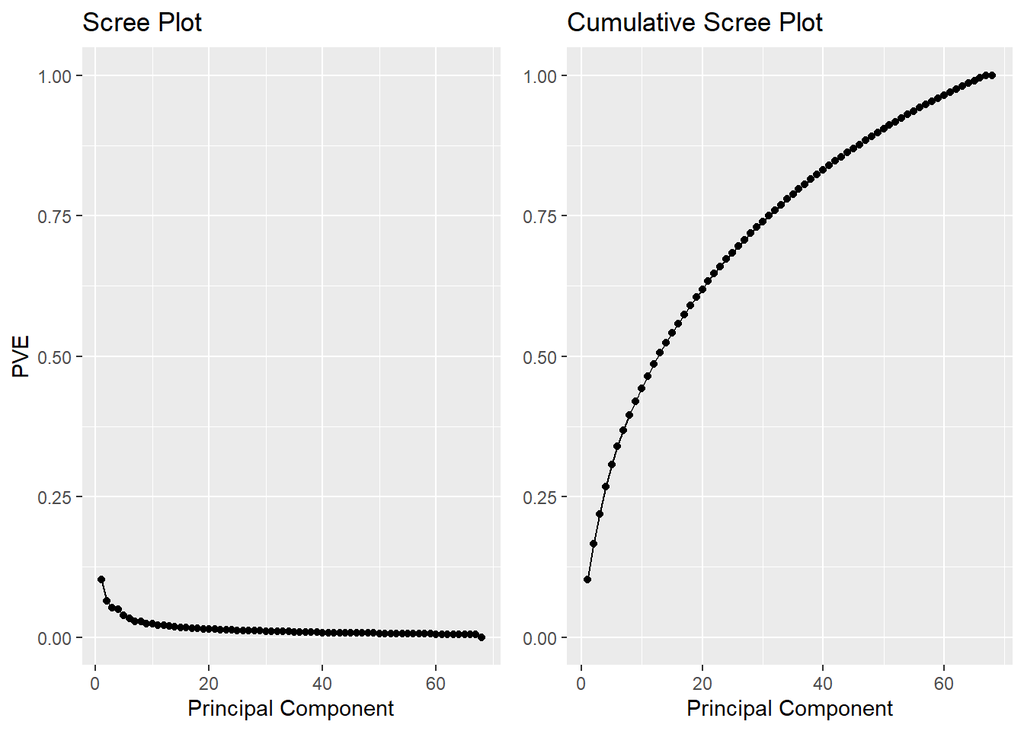

```r
# Gráfico PVE_DigPathology
PVEplot_cleandat <- qplot(c(1:68), PVE_cleandat) +
  geom_line() +
  xlab("Principal Component") +
  ylab("PVE") +
  ggtitle("Scree Plot") +
  ylim(0, 1)
# PVE acumulado
cumPVE_cleandat <- qplot(c(1:68), cumsum(PVE_cleandat)) +
  geom_line() +
  xlab("Principal Component") +
  ylab(NULL) +
  ggtitle("Cumulative Scree Plot") +
  ylim(0,1)

grid.arrange(PVEplot_cleandat, cumPVE_cleandat, ncol = 2)
```

Dibujamos las dos primeras componentes principales y coloreamos según el valor de la variable de clase `cogdx`:

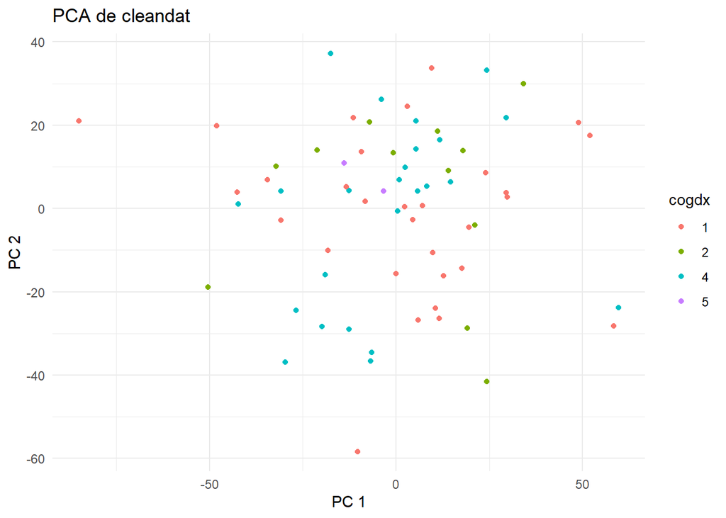

```r
data_pcas_plot_cleandat = as.data.frame(cbind(PC1 = pca_result_cleandat$x[, 1], PC2 = pca_result_cleandat$x[, 2]))
data_pcas_plot_cleandat$cogdx = as.integer(clinical$cogdx)

# Gráfico de componentes principales para el PCA de cleandat usando cogdx
p1_cleandat = ggplot(data = data_pcas_plot_cleandat) + geom_point(aes(x = PC1, y = PC2, col = as.factor(cogdx),)) + theme_minimal()+ labs(x = "PC 1", y = "PC 2", color = "cogdx", title = "PCA de cleandat")

p1_cleandat
```

## 3.2 PCA sobre `metabolon`

Comprobamos si tenemos algún predictor categórico:

```r
which(sapply(colnames(metabolon.prep), function(x) class(metabolon.prep[[x]]) != "numeric") == TRUE)
```

```
## named integer(0)
```

Dado que no hay ninguno, aplicamos PCA:

```r
pca_result_metabolon <- prcomp(metabolon.prep, scale = TRUE, rank=6)
```

Podemos ver la desviación estándar de cada componente principal.

```r
pca_result_metabolon$sdev
```

```
##  [1] 8.940261e+00 7.490701e+00 5.686251e+00 5.205494e+00 5.084365e+00
##  [6] 4.603820e+00 3.977009e+00 3.811998e+00 3.339924e+00 3.267419e+00
## [11] 3.145994e+00 3.031092e+00 2.851926e+00 2.825013e+00 2.746596e+00
## [16] 2.645373e+00 2.542613e+00 2.484991e+00 2.401639e+00 2.275488e+00
## [21] 2.228586e+00 2.196578e+00 2.156867e+00 2.065812e+00 2.048134e+00
## [26] 2.039455e+00 1.985103e+00 1.918268e+00 1.871472e+00 1.838592e+00
## [31] 1.813844e+00 1.791460e+00 1.717467e+00 1.709420e+00 1.675067e+00
## [36] 1.634292e+00 1.569442e+00 1.544578e+00 1.525282e+00 1.497478e+00
## [41] 1.454935e+00 1.421658e+00 1.412187e+00 1.384513e+00 1.377578e+00
## [46] 1.331826e+00 1.269212e+00 1.238742e+00 1.230204e+00 1.208424e+00
## [51] 1.171735e+00 1.157307e+00 1.139449e+00 1.133644e+00 1.116899e+00
## [56] 1.073089e+00 1.036323e+00 1.032475e+00 9.944542e-01 9.834410e-01
## [61] 9.652476e-01 9.381057e-01 9.074229e-01 8.726249e-01 8.651522e-01
## [66] 8.391802e-01 8.153216e-01 3.970273e-15
```

La varianza explicada por cada componente principal se obtiene mediante la cuadratura de estos valores:

```r
(VE_metabolon <- pca_result_metabolon$sdev^2)
```

```
##  [1] 7.992826e+01 5.611061e+01 3.233345e+01 2.709717e+01 2.585077e+01
##  [6] 2.119516e+01 1.581660e+01 1.453133e+01 1.115509e+01 1.067602e+01
## [11] 9.897281e+00 9.187521e+00 8.133484e+00 7.980700e+00 7.543789e+00
## [16] 6.997998e+00 6.464880e+00 6.175182e+00 5.767871e+00 5.177846e+00
## [21] 4.966594e+00 4.824955e+00 4.652074e+00 4.267578e+00 4.194854e+00
## [26] 4.159376e+00 3.940635e+00 3.679753e+00 3.502408e+00 3.380422e+00
## [31] 3.290029e+00 3.209330e+00 2.949694e+00 2.922116e+00 2.805848e+00
## [36] 2.670912e+00 2.463150e+00 2.385721e+00 2.326484e+00 2.242440e+00
## [41] 2.116837e+00 2.021112e+00 1.994273e+00 1.916876e+00 1.897721e+00
## [46] 1.773761e+00 1.610899e+00 1.534482e+00 1.513402e+00 1.460290e+00
## [51] 1.372963e+00 1.339359e+00 1.298344e+00 1.285148e+00 1.247464e+00
## [56] 1.151520e+00 1.073965e+00 1.066005e+00 9.889391e-01 9.671563e-01
## [61] 9.317030e-01 8.800424e-01 8.234164e-01 7.614742e-01 7.484884e-01
## [66] 7.042234e-01 6.647493e-01 1.576307e-29
```

```r
PVE_metabolon <- VE_metabolon / sum(VE_metabolon)
round(PVE_metabolon, 2)
```

```
##  [1] 0.17 0.12 0.07 0.06 0.05 0.04 0.03 0.03 0.02 0.02 0.02 0.02 0.02 0.02 0.02
## [16] 0.01 0.01 0.01 0.01 0.01 0.01 0.01 0.01 0.01 0.01 0.01 0.01 0.01 0.01 0.01
## [31] 0.01 0.01 0.01 0.01 0.01 0.01 0.01 0.01 0.00 0.00 0.00 0.00 0.00 0.00 0.00
## [46] 0.00 0.00 0.00 0.00 0.00 0.00 0.00 0.00 0.00 0.00 0.00 0.00 0.00 0.00 0.00
## [61] 0.00 0.00 0.00 0.00 0.00 0.00 0.00 0.00
```

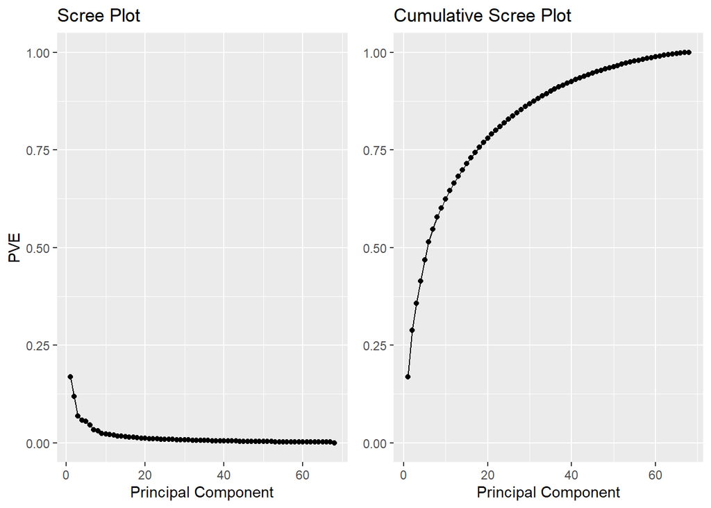

```r
# Gráfico PVE_DigPathology
PVEplot_metabolon <- qplot(c(1:68), PVE_metabolon) +
  geom_line() +
  xlab("Principal Component") +
  ylab("PVE") +
  ggtitle("Scree Plot") +
  ylim(0, 1)

# PVE acumulado
cumPVE_metabolon <- qplot(c(1:68), cumsum(PVE_metabolon)) +
  geom_line() +
  xlab("Principal Component") +
  ylab(NULL) +
  ggtitle("Cumulative Scree Plot") +
  ylim(0,1)

grid.arrange(PVEplot_metabolon, cumPVE_metabolon, ncol = 2)
```

Dibujamos las dos primeras componentes principales y coloreamos según el valor de la variable de clase `cogdx`:

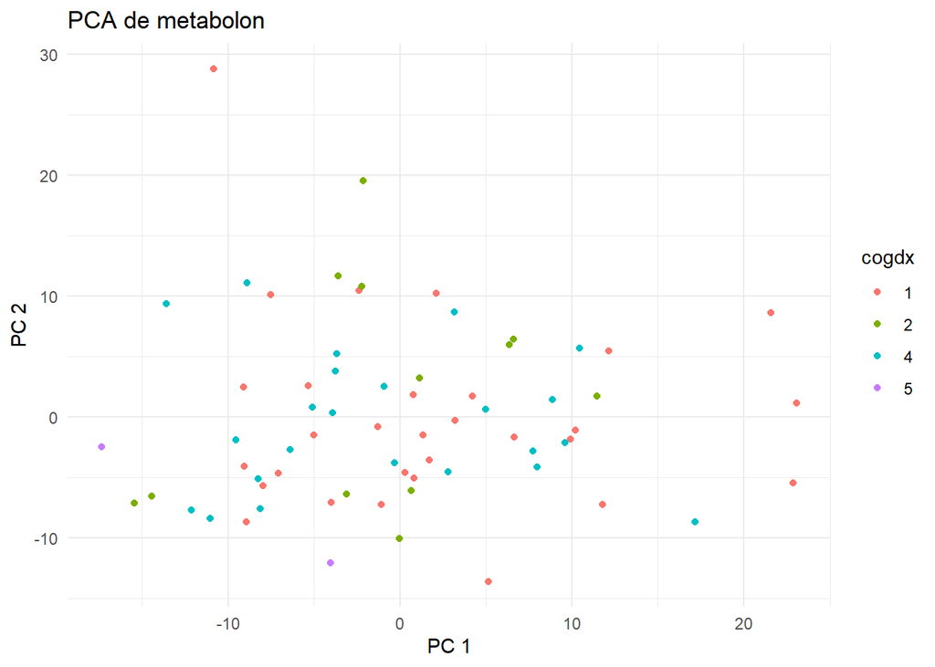

```r
data_pcas_plot_metabolon = as.data.frame(cbind(PC1 = pca_result_metabolon$x[, 1], PC2 = pca_result_metabolon$x[, 2]))
data_pcas_plot_metabolon$cogdx = as.integer(clinical$cogdx)

# Gráfico de componentes principales para el PCA de metabolon usando cogdx
p1_metabolon = ggplot(data = data_pcas_plot_metabolon) + geom_point(aes(x = PC1, y = PC2, col = as.factor(cogdx),)) + theme_minimal()+ labs(x = "PC 1", y = "PC 2", color = "cogdx", title = "PCA de metabolon")

p1_metabolon
```

## 3.3 PCA sobre `rinpmiagesex`

Comprobamos si tenemos algún predictor categórico:

```r
which(sapply(colnames(rinpmiagesex.prep), function(x) class(rinpmiagesex.prep[[x]]) != "numeric") == TRUE)
```

```
## named integer(0)
```

Dado que no hay ninguno, aplicamos PCA:

```r
pca_result_rinpmiagesex <- prcomp(rinpmiagesex.prep, scale = TRUE, rank=6)
```

Podemos ver la desviación estándar de cada componente principal.

```r
pca_result_rinpmiagesex$sdev
```

```
##  [1] 5.496825e+01 3.806345e+01 2.912768e+01 2.451872e+01 2.181735e+01
##  [6] 2.024575e+01 1.933065e+01 1.771379e+01 1.568751e+01 1.453304e+01
## [11] 1.306200e+01 1.297653e+01 1.268132e+01 1.251904e+01 1.210988e+01
## [16] 1.193414e+01 1.134757e+01 1.110757e+01 1.092460e+01 1.055604e+01
## [21] 1.043633e+01 1.023643e+01 1.006862e+01 9.979031e+00 9.789341e+00
## [26] 9.660723e+00 9.588051e+00 9.467437e+00 9.319747e+00 9.218889e+00
## [31] 9.180941e+00 8.961690e+00 8.877980e+00 8.819339e+00 8.731297e+00
## [36] 8.634287e+00 8.585535e+00 8.397096e+00 8.328475e+00 8.280041e+00
## [41] 8.229740e+00 8.170273e+00 8.074242e+00 8.017601e+00 7.995856e+00
## [46] 7.874838e+00 7.829315e+00 7.786280e+00 7.671003e+00 7.504336e+00
## [51] 7.451600e+00 7.438001e+00 7.381453e+00 7.337467e+00 7.274602e+00
## [56] 7.192023e+00 7.178546e+00 7.131569e+00 7.057322e+00 6.979729e+00
## [61] 6.909247e+00 6.869483e+00 6.805791e+00 6.747952e+00 6.662372e+00
## [66] 6.519561e+00 6.334898e+00 3.670462e-14
```

La varianza explicada por cada componente principal se obtiene mediante la cuadratura de estos valores:

```r
(VE_rinpmiagesex <- pca_result_rinpmiagesex$sdev^2)
```

```
##  [1] 3.021509e+03 1.448826e+03 8.484217e+02 6.011675e+02 4.759966e+02
##  [6] 4.098905e+02 3.736741e+02 3.137784e+02 2.460979e+02 2.112092e+02
## [11] 1.706159e+02 1.683903e+02 1.608159e+02 1.567263e+02 1.466492e+02
## [16] 1.424238e+02 1.287673e+02 1.233780e+02 1.193468e+02 1.114300e+02
## [21] 1.089169e+02 1.047844e+02 1.013770e+02 9.958106e+01 9.583119e+01
## [26] 9.332957e+01 9.193071e+01 8.963236e+01 8.685768e+01 8.498791e+01
## [31] 8.428968e+01 8.031188e+01 7.881852e+01 7.778074e+01 7.623554e+01
## [36] 7.455091e+01 7.371141e+01 7.051122e+01 6.936350e+01 6.855908e+01
## [41] 6.772863e+01 6.675337e+01 6.519338e+01 6.428193e+01 6.393371e+01
## [46] 6.201308e+01 6.129818e+01 6.062616e+01 5.884429e+01 5.631507e+01
## [51] 5.552634e+01 5.532386e+01 5.448585e+01 5.383841e+01 5.291983e+01
## [56] 5.172520e+01 5.153153e+01 5.085927e+01 4.980580e+01 4.871662e+01
## [61] 4.773770e+01 4.718979e+01 4.631879e+01 4.553485e+01 4.438720e+01
## [66] 4.250467e+01 4.013093e+01 1.347229e-27
```

```r
PVE_rinpmiagesex <- VE_rinpmiagesex / sum(VE_rinpmiagesex)
round(PVE_rinpmiagesex, 2)
```

```
##  [1] 0.24 0.12 0.07 0.05 0.04 0.03 0.03 0.02 0.02 0.02 0.01 0.01 0.01 0.01 0.01
## [16] 0.01 0.01 0.01 0.01 0.01 0.01 0.01 0.01 0.01 0.01 0.01 0.01 0.01 0.01 0.01
## [31] 0.01 0.01 0.01 0.01 0.01 0.01 0.01 0.01 0.01 0.01 0.01 0.01 0.01 0.01 0.01
## [46] 0.00 0.00 0.00 0.00 0.00 0.00 0.00 0.00 0.00 0.00 0.00 0.00 0.00 0.00 0.00
## [61] 0.00 0.00 0.00 0.00 0.00 0.00 0.00 0.00
```

En la primera componente se explica el 24% de la variabilidad, mientras que en la segunda el 12%. Entre las dos primeras componentes se explica un 36% de la variabilidad. Esto lo podemos visualizar en las siguientes gráficas:

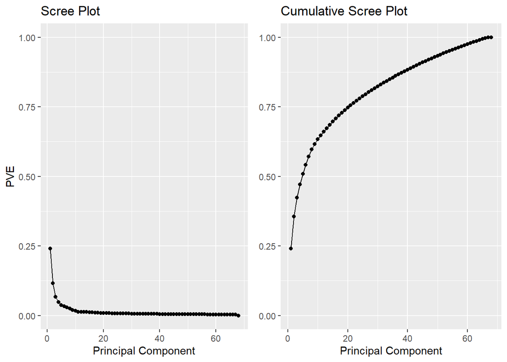

```r
# Gráfico PVE_DigPathology
PVEplot_rinpmiagesex <- qplot(c(1:68), PVE_rinpmiagesex) +
  geom_line() +
  xlab("Principal Component") +
  ylab("PVE") +
  ggtitle("Scree Plot") +
  ylim(0, 1)

# PVE acumulado
cumPVE_rinpmiagesex <- qplot(c(1:68), cumsum(PVE_rinpmiagesex)) +
  geom_line() +
  xlab("Principal Component") +
  ylab(NULL) +
  ggtitle("Cumulative Scree Plot") +
  ylim(0,1)

grid.arrange(PVEplot_rinpmiagesex, cumPVE_rinpmiagesex, ncol = 2)
```

Dibujamos las dos primeras componentes principales y coloreamos según el valor de la variable de clase `cogdx`:

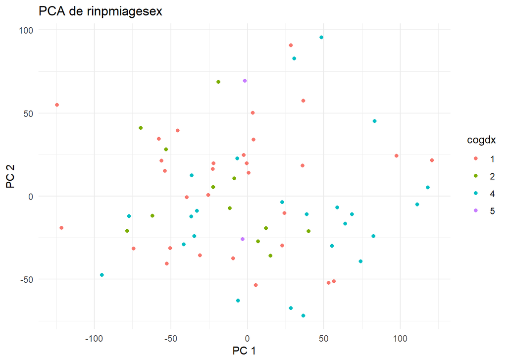

```r
data_pcas_plot_rinpmiagesex = as.data.frame(cbind(PC1 = pca_result_rinpmiagesex$x[, 1], PC2 = pca_result_rinpmiagesex$x[, 2]))
data_pcas_plot_rinpmiagesex$cogdx = as.integer(clinical$cogdx)

# Gráfico de componentes principales para el PCA de rinpmiagesex usando cogdx
p1_rinpmiagesex = ggplot(data = data_pcas_plot_rinpmiagesex) + geom_point(aes(x = PC1, y = PC2, col = as.factor(cogdx),)) + theme_minimal()+ labs(x = "PC 1", y = "PC 2", color = "cogdx", title = "PCA de rinpmiagesex")

p1_rinpmiagesex
```

## 3.4 Correlaciones

Calculamos las matrices de correlación entre cada par de conjuntos de datos:

```r
# Calculamos las matrices de correlación
cor_cleandat_metabolon = cor(pca_result_cleandat$x, pca_result_metabolon$x)
cor_cleandat_rinpmiagesex = cor(pca_result_cleandat$x, pca_result_rinpmiagesex$x)
cor_metabolon_rinpmiagesex = cor(pca_result_metabolon$x, pca_result_rinpmiagesex$x)
```

## 3.5 Aplicamos bosques aleatorios

Para finalizar con los datos de PCA, introducimos los tres PCAs en un único conjunto de datos y aplicamos la técnica de aprendizaje computacional `bosques aleatorios`.

Combinamos los tres conjuntos de datos resultantes de la aplicación de los PCAs:

```r
# Combinamos los tres conjuntos de datos resultantes de la aplicación de los PCAs
pca_result_total_ROSMAP = cbind(pca_result_cleandat$x, pca_result_metabolon$x, pca_result_rinpmiagesex$x)

# Lo establecemos como `data.frame`
pca_result_total_ROSMAP = as.data.frame(pca_result_total_ROSMAP)

# Cambiamos el nombre de las columnas
colnames(pca_result_total_ROSMAP) <- c("PC_cleandat_1", "PC_cleandat_2", "PC_cleandat_3", "PC_cleandat_4", "PC_cleandat_5", "PC_cleandat_6", "PC_metabolon_1", "PC_metabolon_2", "PC_metabolon_3", "PC_metabolon_4", "PC_metabolon_5", "PC_metabolon_6", "PC_rinpmiagesex_1", "PC_rinpmiagesex_2", "PC_rinpmiagesex_3", "PC_rinpmiagesex_4", "PC_rinpmiagesex_5", "PC_rinpmiagesex_6")

# Añadimos la variable de clase `cogdx`
pca_result_total_ROSMAP = cbind(pca_result_total_ROSMAP, clinical$cogdx)

# Le cambiamos el nombre a la columna `cogdx` para que se llame `cogdx`
colnames(pca_result_total_ROSMAP)[19] = c("cogdx")

# Indicamos que la variable de clase `cogdx` es de tipo `factor`
pca_result_total_ROSMAP$cogdx = as.factor(pca_result_total_ROSMAP$cogdx)
```

Dividimos los datos para poder hacer el entrenamiento:

```r
pca_result_total_ROSMAP.Var.Salida.Usada = c("cogdx")
pca_result_total_ROSMAP.Var.Entrada.Usadas = setdiff(names(pca_result_total_ROSMAP), pca_result_total_ROSMAP.Var.Salida.Usada)

pca_result_total_ROSMAP.TrainIdx.80 <- createDataPartition(pca_result_total_ROSMAP[[pca_result_total_ROSMAP.Var.Salida.Usada]],
                                   p = 0.8,
                                   list = FALSE,
                                   times = 1)

pca_result_total_ROSMAP.Train <- pca_result_total_ROSMAP[pca_result_total_ROSMAP.TrainIdx.80,]
pca_result_total_ROSMAP.Test <- pca_result_total_ROSMAP[-pca_result_total_ROSMAP.TrainIdx.80,]
```

Creamos un grid de hiperparámetros con los siguientes datos para poder ver cuál de estas combinaciones es la mejor. Introducimos valores 8 y 12 para `mtry`, este valor no puede crecer mucho más debido a que tenemos 18 variables en nuestro conjunto de datos; `gini` y `extratrees` para `splitrule`, para ver cuál de todas estas reglas funciona mejor; y a `min.node.size` le asignamos los valores 5, 10 y 15, así podremos ver en los resultados si el algoritmo nos pide mayor o menor potencia.

```r
mygrid = expand.grid(mtry = c(8,12),
                     splitrule=c("gini","extratrees"),
                     min.node.size  =c(5,10,15))
print(mygrid)
```

```
##    mtry  splitrule min.node.size
## 1     8       gini             5
## 2    12       gini             5
## 3     8 extratrees             5
## 4    12 extratrees             5
## 5     8       gini            10
## 6    12       gini            10
## 7     8 extratrees            10
## 8    12 extratrees            10
## 9     8       gini            15
## 10   12       gini            15
## 11    8 extratrees            15
## 12   12 extratrees            15
```

```r
fitControl <- trainControl(## 5-fold CV
                           method = "repeatedcv",
                           number = 3,
                           repeats = 50)
```

```r
rangerFit <- train(pca_result_total_ROSMAP.Train[pca_result_total_ROSMAP.Var.Entrada.Usadas],
                 pca_result_total_ROSMAP.Train[[pca_result_total_ROSMAP.Var.Salida.Usada]],
                 method = "ranger",
                 trControl = fitControl,
                 tuneGrid = mygrid,
                 num.trees = 15,
                 importance='impurity')

# Guardamos los resultados
saveRDS(rangerFit, file = "bosquesAleatorios_PCA_ROSMAP_1.rds")
```

Leemos los datos y los imprimimos por pantalla:

```r
rangerFit <- readRDS(file = "bosquesAleatorios_PCA_ROSMAP_1.rds")
rangerFit
```

[output not shown]

Realizamos la predicción del conjunto de entrenamiento:

```r
pred.train <- predict(rangerFit, pca_result_total_ROSMAP.Train[pca_result_total_ROSMAP.Var.Entrada.Usadas])
confusionMatrix(data = pred.train, reference = pca_result_total_ROSMAP.Train[[pca_result_total_ROSMAP.Var.Salida.Usada]])
```

```
## Confusion Matrix and Statistics
##
##           Reference
## Prediction  1  2  4  5
##          1 22  9 12  1
##          2  0  0  0  0
##          4  2  1  8  1
##          5  0  0  0  0
##
## Overall Statistics
##
##                Accuracy : 0.5357
##                  95% CI : (0.3974, 0.6701)
##     No Information Rate : 0.4286
##     P-Value [Acc > NIR] : 0.06941
##
##                   Kappa : 0.2087
##
##  Mcnemar's Test P-Value : NA
##
## Statistics by Class:
##
##                      Class: 1 Class: 2 Class: 4 Class: 5
## Sensitivity            0.9167   0.0000   0.4000  0.00000
## Specificity            0.3125   1.0000   0.8889  1.00000
## Pos Pred Value         0.5000      NaN   0.6667      NaN
## Neg Pred Value         0.8333   0.8214   0.7273  0.96429
## Prevalence             0.4286   0.1786   0.3571  0.03571
## Detection Rate         0.3929   0.0000   0.1429  0.00000
## Detection Prevalence   0.7857   0.0000   0.2143  0.00000
## Balanced Accuracy      0.6146   0.5000   0.6444  0.50000
```

Realizamos la predicción del conjunto de validación:

```r
pred.test_PCA_ROSMAP <- predict(rangerFit, pca_result_total_ROSMAP.Test[pca_result_total_ROSMAP.Var.Entrada.Usadas])
confusionMatrix(data = pred.test_PCA_ROSMAP, reference = pca_result_total_ROSMAP.Test[[pca_result_total_ROSMAP.Var.Salida.Usada]])
```

```
## Confusion Matrix and Statistics
##
##           Reference
## Prediction 1 2 4 5
##          1 4 2 3 0
##          2 0 0 0 0
##          4 2 0 1 0
##          5 0 0 0 0
##
## Overall Statistics
##
##                Accuracy : 0.4167
##                  95% CI : (0.1517, 0.7233)
##     No Information Rate : 0.5
##     P-Value [Acc > NIR] : 0.8062
##
##                   Kappa : -0.0769
##
##  Mcnemar's Test P-Value : NA
##
## Statistics by Class:
##
##                      Class: 1 Class: 2 Class: 4 Class: 5
## Sensitivity            0.6667   0.0000  0.25000       NA
## Specificity            0.1667   1.0000  0.75000        1
## Pos Pred Value         0.4444      NaN  0.33333       NA
## Neg Pred Value         0.3333   0.8333  0.66667       NA
## Prevalence             0.5000   0.1667  0.33333        0
## Detection Rate         0.3333   0.0000  0.08333        0
## Detection Prevalence   0.7500   0.0000  0.25000        0
## Balanced Accuracy      0.4167   0.5000  0.50000       NA
```

# 4 SMCCA-GS

Procedemos ahora a aplicar SMCCA-GS a los tres conjuntos de datos:

## 4.1 SMCCA-GS sobre `cleandat`, `metabolon`, `rinpmiagesex`

Aplicamos `SMCCA-GS` sobre los conjuntos de datos `cleandat`, `metabolon` y `rinpmiagesex` utilizando seis variables canónicas:

```r
moData = list(cleandat.prep, metabolon.prep, rinpmiagesex.prep)
ncomponentes=6
opt_num = "full"
SMCCA_GS_out_ROSMAP = MultiCCA_GS(moData, ncomponents=ncomponentes, opt_num = opt_num)
saveRDS(SMCCA_GS_out_ROSMAP, file = "SMCCA_GS_out_cleandat_metabolon_rinpmiagesex.rds")
```

Leemos los resultados obtenidos tras aplicar SMCCA-GS:

```r
SMCCA_GS_out_ROSMAP <- readRDS("SMCCA_GS_out_cleandat_metabolon_rinpmiagesex.rds")
print(names(SMCCA_GS_out_ROSMAP))
```

```
## [1] "canon_var" "weight"    "penalty"
```

Antes de dibujar los puntos vamos a ver brevemente si hemos aplicado correctamente la técnica SMCCA-GS:

```r
cv_x1_ROSMAP = SMCCA_GS_out_ROSMAP$canon_var[[1]]
cv_x2_ROSMAP = SMCCA_GS_out_ROSMAP$canon_var[[2]]
cv_x3_ROSMAP = SMCCA_GS_out_ROSMAP$canon_var[[3]]
print(sprintf("The dimension of CV X1 is %d x %d.", dim(cv_x1_ROSMAP)[1], dim(cv_x1_ROSMAP)[2]))
```

```
## [1] "The dimension of CV X1 is 68 x 6."
```

```r
print(sprintf("The dimension of CV X2 is %d x %d.", dim(cv_x2_ROSMAP)[1], dim(cv_x2_ROSMAP)[2]))
```

```
## [1] "The dimension of CV X2 is 68 x 6."
```

```r
print(sprintf("The dimension of CV X3 is %d x %d.", dim(cv_x3_ROSMAP)[1], dim(cv_x3_ROSMAP)[2]))
```

```
## [1] "The dimension of CV X3 is 68 x 6."
```

```r
cv_w1_ROSMAP = SMCCA_GS_out_ROSMAP$weight[[1]]
cv_w2_ROSMAP = SMCCA_GS_out_ROSMAP$weight[[2]]
cv_w3_ROSMAP = SMCCA_GS_out_ROSMAP$weight[[3]]
print(sprintf("The dimension of weight X1 is %d x %d.", dim(cv_w1_ROSMAP)[1], dim(cv_w1_ROSMAP)[2]))
```

```
## [1] "The dimension of weight X1 is 6664 x 6."
```

```r
print(sprintf("The dimension of weight X2 is %d x %d.", dim(cv_w2_ROSMAP)[1], dim(cv_w2_ROSMAP)[2]))
```

```
## [1] "The dimension of weight X2 is 472 x 6."
```

```r
print(sprintf("The dimension of weight X3 is %d x %d.", dim(cv_w3_ROSMAP)[1], dim(cv_w3_ROSMAP)[2]))
```

```
## [1] "The dimension of weight X3 is 12556 x 6."
```

Las matrices de pesos también tienen las dimensiones esperadas. Las filas se corresponden con los predictores de cada conjunto de datos y las columnas con las variables canónicas (VC por sus siglas en español). Estas matrices nos indican el peso que tiene cada predictor en cada VC.

## 4.2 Comparativa entre las variables canónicas obtenidas

Veamos si SMCCA-GS ha tenido en cuenta los distintos conjuntos de datos para calcular las variables canónicas de cada método:

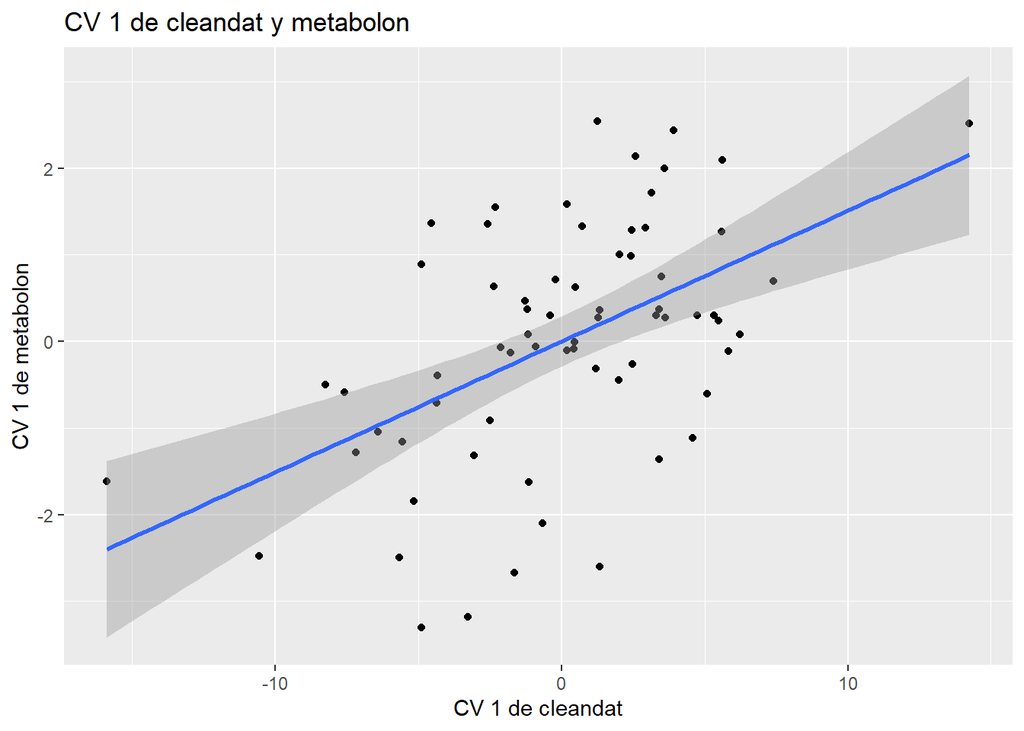

```r
data_SMCCA_GS_cleandat_metabolon = as.data.frame(cbind(CV1_cleandat = cv_x1_ROSMAP[, 1], CV1_metabolon = cv_x2_ROSMAP[, 1]))
ggplot(data = data_SMCCA_GS_cleandat_metabolon) + geom_point(aes(x = CV1_cleandat, y = CV1_metabolon)) + geom_smooth(method = "lm", aes(x = CV1_cleandat, y = CV1_metabolon)) + labs(x = "CV 1 de cleandat", y = "CV 1 de metabolon", title = "CV 1 de cleandat y metabolon")
```

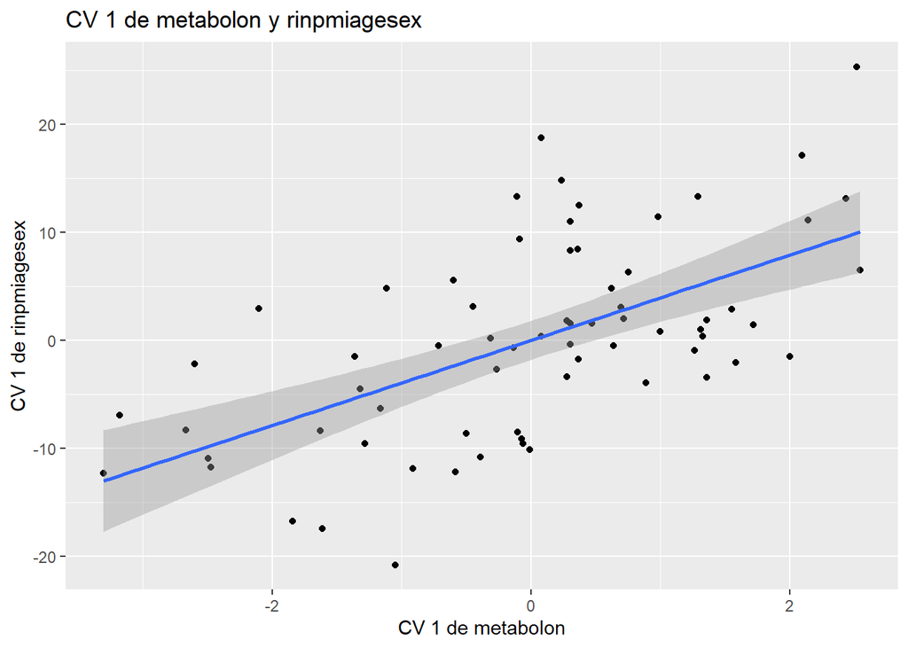

```r
data_SMCCA_GS_metabolon_rinpmiagesex = as.data.frame(cbind(CV1_metabolon = cv_x2_ROSMAP[, 1], CV1_rinpmiagesex = cv_x3_ROSMAP[, 1]))
ggplot(data = data_SMCCA_GS_metabolon_rinpmiagesex) + geom_point(aes(x = CV1_metabolon, y = CV1_rinpmiagesex)) + geom_smooth(method = "lm", aes(x = CV1_metabolon, y = CV1_rinpmiagesex)) + labs(x = "CV 1 de metabolon", y = "CV 1 de rinpmiagesex", title = "CV 1 de metabolon y rinpmiagesex")
```

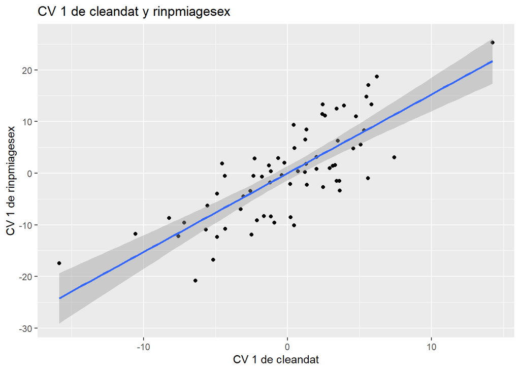

```r
data_SMCCA_GS_cleandat_rinpmiagesex = as.data.frame(cbind(CV1_cleandat = cv_x1_ROSMAP[, 1], CV1_rinpmiagesex = cv_x3_ROSMAP[, 1]))
ggplot(data = data_SMCCA_GS_cleandat_rinpmiagesex) + geom_point(aes(x = CV1_cleandat, y = CV1_rinpmiagesex)) + geom_smooth(method = "lm", aes(x = CV1_cleandat, y = CV1_rinpmiagesex)) + labs(x = "CV 1 de cleandat", y = "CV 1 de rinpmiagesex", title = "CV 1 de cleandat y rinpmiagesex")
```

Estos gráficos tienen, para cada par de conjuntos de datos, en el eje “X” la primera variable canónica de uno de los conjuntos de datos y en el eje “Y” la primera variable canónica de otro de los conjuntos de datos. Con estas gráficas, pretendemos visualizar si las variables canónicas obtenidas entre los distintos conjuntos de datos están correlacionadas entre sí, pues queremos comprobar una de las principales ventajas de SMCCA-GS, y es que tiene en cuenta todos los conjuntos de datos para calcular las variables canónicas.

Veamos si el p-valor del test de correlación es significativo:

```r
# Calculamos el test de correlación
cor_test_cleandat_metabolon <- cor.test(data_SMCCA_GS_cleandat_metabolon$CV1_cleandat, data_SMCCA_GS_cleandat_metabolon$CV1_metabolon)
cor_test_metabolon_rinpmiagesex <- cor.test(data_SMCCA_GS_metabolon_rinpmiagesex$CV1_metabolon, data_SMCCA_GS_metabolon_rinpmiagesex$CV1_rinpmiagesex)
cor_test_cleandat_rinpmiagesex <- cor.test(data_SMCCA_GS_cleandat_rinpmiagesex$CV1_cleandat, data_SMCCA_GS_cleandat_rinpmiagesex$CV1_rinpmiagesex)

# Obtenemos los p-valores
cor_test_cleandat_metabolon$p.value
```

```
## [1] 6.145537e-06
```

```r
cor_test_metabolon_rinpmiagesex$p.value
```

```
## [1] 9.434512e-08
```

```r
cor_test_cleandat_rinpmiagesex$p.value
```

```
## [1] 1.726257e-15
```

| Pares de conjuntos de datos | p-valor |
| --- | --- |
| cleandat - metabolon | 6.145537e-06 |
| metabolon - rinpmiagesex | 9.434512e-08 |
| cleandat - rinpmiagesex | 1.726257e-15 |

Efectivamente, en los tres casos observamos que el p-valor es menor que el valor de significancia (0.05), por lo que hay una correlación significativa entre ellos.

## 4.3 Representación gráfica

### 4.3.1 cleandat

Conjunto `cleandat`:

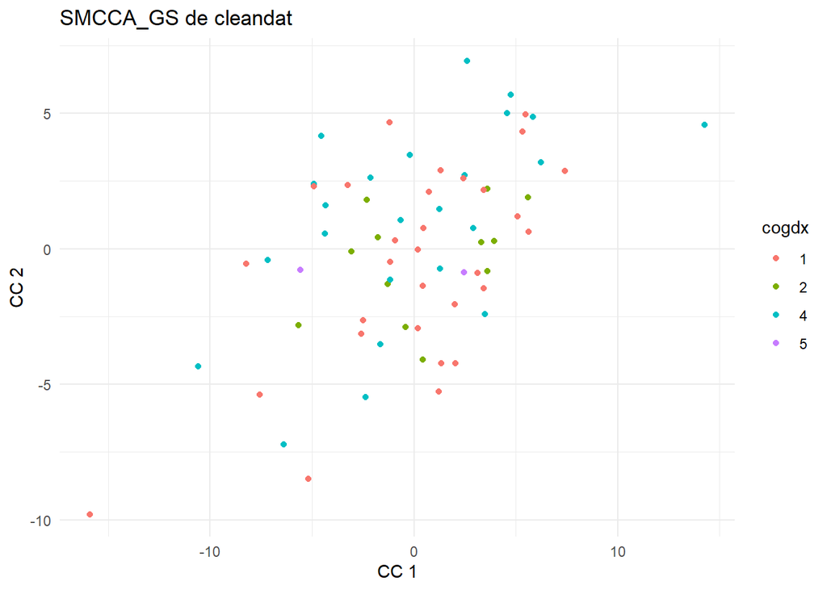

```r
data_SMCCA_GS_plot_cleandat = as.data.frame(cbind(CC1 = cv_x1_ROSMAP[, 1], CC2 = cv_x1_ROSMAP[, 2]))
data_SMCCA_GS_plot_cleandat$cogdx = as.integer(clinical$cogdx)

# Gráfico de las variables canónicas principales para el SMCCA-GS de cleandat usando cogdx
c1_cleandat = ggplot(data = data_SMCCA_GS_plot_cleandat) + geom_point(aes(x = CC1, y = CC2, col = as.factor(cogdx),)) + theme_minimal()+ labs(x = "CC 1", y = "CC 2", color = "cogdx", title = "SMCCA_GS de cleandat")

c1_cleandat
```

### 4.3.2 metabolon

Conjunto `metabolon`:

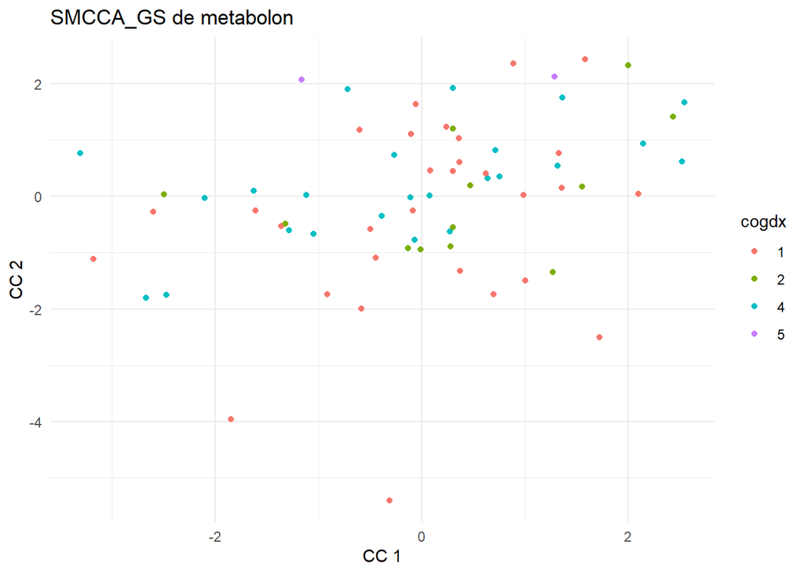

```r
data_SMCCA_GS_plot_metabolon = as.data.frame(cbind(CC1 = cv_x2_ROSMAP[, 1], CC2 = cv_x2_ROSMAP[, 2]))
data_SMCCA_GS_plot_metabolon$cogdx = as.integer(clinical$cogdx)

# Gráfico de las variables canónicas principales para el SMCCA-GS de metabolon usando cogdx
c1_metabolon = ggplot(data = data_SMCCA_GS_plot_metabolon) + geom_point(aes(x = CC1, y = CC2, col = as.factor(cogdx),)) + theme_minimal()+ labs(x = "CC 1", y = "CC 2", color = "cogdx", title = "SMCCA_GS de metabolon")

c1_metabolon
```

### 4.3.3 rinpmiagesex

Conjunto `rinpmiagesex`:

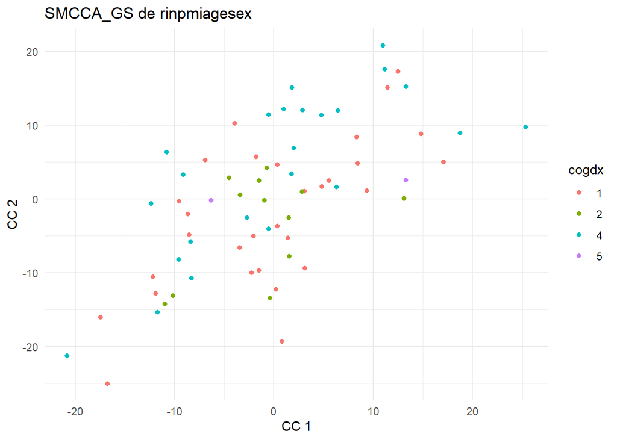

```r
data_SMCCA_GS_plot_rinpmiagesex = as.data.frame(cbind(CC1 = cv_x3_ROSMAP[, 1], CC2 = cv_x3_ROSMAP[, 2]))
data_SMCCA_GS_plot_rinpmiagesex$cogdx = as.integer(clinical$cogdx)

# Gráfico de las variables canónicas principales para el SMCCA-GS de rinpmiagesex usando cogdx
c1_rinpmiagesex = ggplot(data = data_SMCCA_GS_plot_rinpmiagesex) + geom_point(aes(x = CC1, y = CC2, col = as.factor(cogdx),)) + theme_minimal()+ labs(x = "CC 1", y = "CC 2", color = "cogdx", title = "SMCCA_GS de rinpmiagesex")

c1_rinpmiagesex
```

## 4.4 Correlaciones

Calculamos las matrices de correlación entre cada par de conjuntos de datos:

```r
# Calculamos las matrices de correlación
cor_SMCCA_GS_cleandat_metabolon = cor(cv_x1_ROSMAP, cv_x2_ROSMAP)
cor_SMCCA_GS_cleandat_rinpmiagesex = cor(cv_x1_ROSMAP, cv_x3_ROSMAP)
cor_SMCCA_GS_metabolon_rinpmiagesex = cor(cv_x2_ROSMAP, cv_x3_ROSMAP)
```